# ps_5

James Hutt

16/03/2020

## Mad Libs

ML 1) Not all respondents were asked every question. 2672 respondents were asked the question about whether the USA should create a gun registry.

ML 2) Of the respondents that got asked all four gun policy questions, 23.73 percent are gun owners. (For the purposes of this question, you can assume that the people who answered “not sure” are not gun owners). Round to 2 digits after the decimal point.

ML 3) The average “agreement” score (from 1-4) on the statement_gun_rights variable is 2.05 for those respondents who live in households without guns, while the average “agreement” score in households with guns is 2.60. (Calculate the average dropping respondents who weren’t asked, didn’t know, or skipped either question, and round to two digits after the decimal point).

ML 4) Another set of questions asks about religion. The first ranked category of religion for the age group of people 18-30 (don’t include 30) is “Nothing in particular” . The first-ranked religion category for people 30 and older is “Catholic”. Hint: you’re going to need the “labels” that are imported from the dta using haven; we suggest using as_factor to assign the right labels to the religion variable.

ML 5) Lots of people say that the younger generation has the highest percent of “nones;” people who answer “nothing in particular”, when you ask them their religion. In the 18-30 age group, “nothing in particular” is ranked 1, while in the 30 and above group, “nothing in particular” is ranked 4.

ML 6) Consider again the nones (all people who responded “nothing in particular”) when asked about their religion. In this group, the most popular position is to Strongly Agree (strongly disagree, disagree, agree, or strongly agree?) that it is more important for the government to control who owns guns than it is for the government to protect the right to own guns (use the variable “statement_gun_rights” and only include respondents who were asked both of these questions).

## Q2: Simulations with List Columns

#### Part D

Drawing Two Cards

Card colours

| Draw | First card red? | Second card red? | Colour Outcome |
| --- | --- | --- | --- |
| spades, diamonds | FALSE | TRUE | Mixed |
| hearts, spades | TRUE | FALSE | Mixed |
| hearts, spades | TRUE | FALSE | Mixed |
| spades, hearts | FALSE | TRUE | Mixed |
| diamonds, clubs | TRUE | FALSE | Mixed |
| clubs, diamonds | FALSE | TRUE | Mixed |
| clubs, diamonds | FALSE | TRUE | Mixed |
| hearts, clubs | TRUE | FALSE | Mixed |
| clubs, diamonds | FALSE | TRUE | Mixed |
| diamonds, spades | TRUE | FALSE | Mixed |

#### Part E

In my simulation of drawing 2 cards 1000 times 51.2% of the pairs have mixed colours.

## Q3: Modeling a Study Population

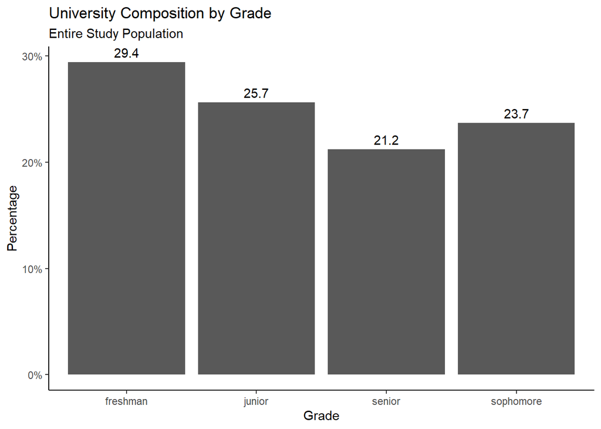

## Q4: Sampling

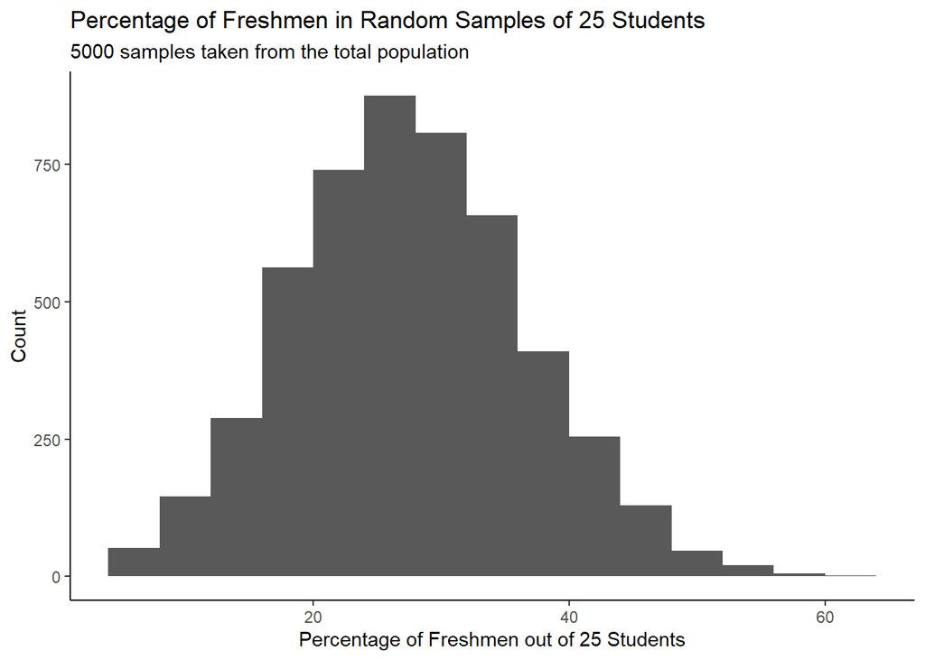

## Q5: Sampling and Sample Size

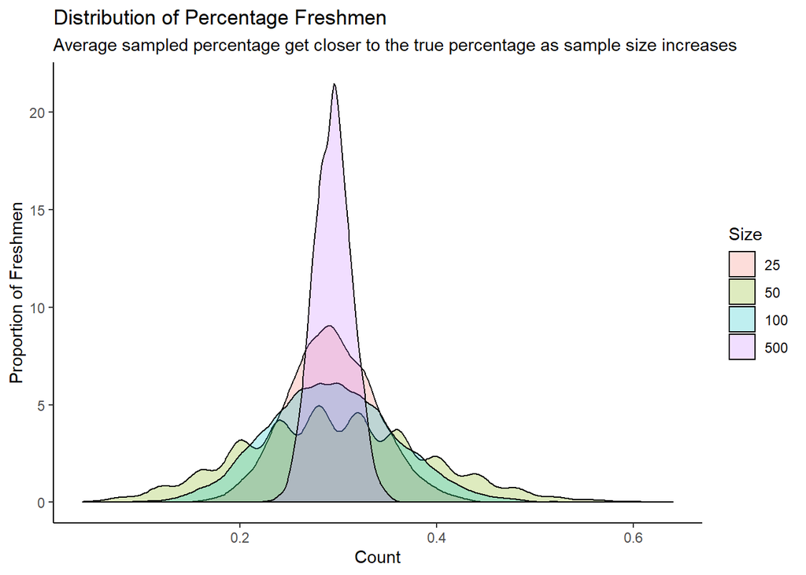

## Q6: Publish Your Plot

URL: https://rpubs.com/huttjames/585816

Included graphic:

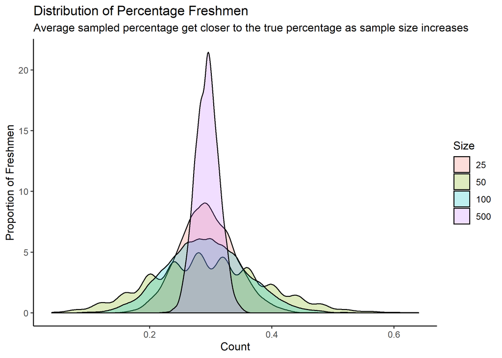

## Q7: Reprex

URL: https://github.com/GOV-1005-Spring-2020/problem-set-5-huttjames/issues/1

## Q8: Demonstrating Understanding of Sampling

I would choose to sample 500 people from each of the 10 states rather than 1000 people in just the 5 cities. Since the vote is decided by a popular vote of the whole population, then the entire population of the country is really my study population. Its impossible to do a census (assuming that there are more than 5000 people in my country) so my challenge becomes one of finding a representative sample from which I can generalize. The population of cities is not random characteristics – they tend to consistently be younger and more liberal - and consequently cities have unrepresentative political. Any poll which covered just the cities would be unrepresentative and the point estimates generated would not necessarily be good guesses of the population parameters. They would be biased estimates. By taking smaller samples I will, necessarily, increase sampling variation and so the confidence intervals for each individual state will be wider. Nonetheless, I can combine the 10 polls together to create a national poll. In doing this I may have to weight the polls so that the relative population differences between states are accounted for. But if there are only 10 states and I sample in the correct weight from each of them, then my estimate should be an unbiased estimate of the whole population, which, ultimately is what I care about. I may further be interested in local variation in views, because this would allow me to target my last ditch campaign efforts, but with just a week to go until elections and targeted campaigning is likely to be limited in scope. Given the electoral system is truly 1-person-1vote, there is no advantage to winning marginal states, so I would like a poll which covers every voter rather than a poll which focuses on key local areas.